# Risk Factor Analysis

## Outcome Variable

**Outcome Variable:** ever_co

## Predictor Variables

**Intervention Variable:** predfeed36

**Adjustment Set:**

unadjusted

## Stratifying Variables

The analysis was stratified on these variable(s):

- agecat
- studyid
- country

## Data Summary

| agecat | studyid | country | predfeed36 | ever_co | n_cell | n |
| --- | --- | --- | --- | --- | --- | --- |
| 0-24 months | EE | PAKISTAN | 1 | 0 | 3 | 9 |
| 0-24 months | EE | PAKISTAN | 1 | 1 | 1 | 9 |
| 0-24 months | EE | PAKISTAN | 0 | 0 | 5 | 9 |
| 0-24 months | EE | PAKISTAN | 0 | 1 | 0 | 9 |
| 0-24 months | GMS-Nepal | NEPAL | 1 | 0 | 286 | 528 |
| 0-24 months | GMS-Nepal | NEPAL | 1 | 1 | 137 | 528 |
| 0-24 months | GMS-Nepal | NEPAL | 0 | 0 | 64 | 528 |
| 0-24 months | GMS-Nepal | NEPAL | 0 | 1 | 41 | 528 |
| 0-24 months | JiVitA-3 | BANGLADESH | 1 | 0 | 9017 | 12748 |
| 0-24 months | JiVitA-3 | BANGLADESH | 1 | 1 | 925 | 12748 |
| 0-24 months | JiVitA-3 | BANGLADESH | 0 | 0 | 2527 | 12748 |
| 0-24 months | JiVitA-3 | BANGLADESH | 0 | 1 | 279 | 12748 |
| 0-24 months | JiVitA-4 | BANGLADESH | 1 | 0 | 3023 | 4589 |
| 0-24 months | JiVitA-4 | BANGLADESH | 1 | 1 | 533 | 4589 |
| 0-24 months | JiVitA-4 | BANGLADESH | 0 | 0 | 821 | 4589 |
| 0-24 months | JiVitA-4 | BANGLADESH | 0 | 1 | 212 | 4589 |
| 0-24 months | LCNI-5 | MALAWI | 1 | 0 | 44 | 272 |
| 0-24 months | LCNI-5 | MALAWI | 1 | 1 | 3 | 272 |
| 0-24 months | LCNI-5 | MALAWI | 0 | 0 | 212 | 272 |
| 0-24 months | LCNI-5 | MALAWI | 0 | 1 | 13 | 272 |
| 0-24 months | MAL-ED | BANGLADESH | 1 | 0 | 71 | 251 |
| 0-24 months | MAL-ED | BANGLADESH | 1 | 1 | 14 | 251 |
| 0-24 months | MAL-ED | BANGLADESH | 0 | 0 | 141 | 251 |
| 0-24 months | MAL-ED | BANGLADESH | 0 | 1 | 25 | 251 |
| 0-24 months | MAL-ED | BRAZIL | 1 | 0 | 28 | 224 |
| 0-24 months | MAL-ED | BRAZIL | 1 | 1 | 1 | 224 |
| 0-24 months | MAL-ED | BRAZIL | 0 | 0 | 193 | 224 |
| 0-24 months | MAL-ED | BRAZIL | 0 | 1 | 2 | 224 |
| 0-24 months | MAL-ED | INDIA | 1 | 0 | 17 | 239 |
| 0-24 months | MAL-ED | INDIA | 1 | 1 | 1 | 239 |

[output cut: 126 more lines]

The following strata were considered:

- agecat: 0-24 months, studyid: EE, country: PAKISTAN
- agecat: 0-24 months, studyid: GMS-Nepal, country: NEPAL
- agecat: 0-24 months, studyid: JiVitA-3, country: BANGLADESH
- agecat: 0-24 months, studyid: JiVitA-4, country: BANGLADESH
- agecat: 0-24 months, studyid: LCNI-5, country: MALAWI
- agecat: 0-24 months, studyid: MAL-ED, country: BANGLADESH
- agecat: 0-24 months, studyid: MAL-ED, country: BRAZIL
- agecat: 0-24 months, studyid: MAL-ED, country: INDIA
- agecat: 0-24 months, studyid: MAL-ED, country: NEPAL
- agecat: 0-24 months, studyid: MAL-ED, country: PERU
- agecat: 0-24 months, studyid: MAL-ED, country: SOUTH AFRICA
- agecat: 0-24 months, studyid: MAL-ED, country: TANZANIA, UNITED REPUBLIC OF
- agecat: 0-24 months, studyid: SAS-FoodSuppl, country: INDIA
- agecat: 0-6 months, studyid: EE, country: PAKISTAN
- agecat: 0-6 months, studyid: GMS-Nepal, country: NEPAL
- agecat: 0-6 months, studyid: JiVitA-3, country: BANGLADESH
- agecat: 0-6 months, studyid: JiVitA-4, country: BANGLADESH
- agecat: 0-6 months, studyid: LCNI-5, country: MALAWI
- agecat: 0-6 months, studyid: MAL-ED, country: BANGLADESH
- agecat: 0-6 months, studyid: MAL-ED, country: BRAZIL
- agecat: 0-6 months, studyid: MAL-ED, country: INDIA
- agecat: 0-6 months, studyid: MAL-ED, country: NEPAL
- agecat: 0-6 months, studyid: MAL-ED, country: PERU
- agecat: 0-6 months, studyid: MAL-ED, country: SOUTH AFRICA
- agecat: 0-6 months, studyid: MAL-ED, country: TANZANIA, UNITED REPUBLIC OF
- agecat: 0-6 months, studyid: SAS-FoodSuppl, country: INDIA
- agecat: 6-24 months, studyid: EE, country: PAKISTAN
- agecat: 6-24 months, studyid: GMS-Nepal, country: NEPAL
- agecat: 6-24 months, studyid: JiVitA-3, country: BANGLADESH
- agecat: 6-24 months, studyid: JiVitA-4, country: BANGLADESH
- agecat: 6-24 months, studyid: LCNI-5, country: MALAWI
- agecat: 6-24 months, studyid: MAL-ED, country: BANGLADESH
- agecat: 6-24 months, studyid: MAL-ED, country: BRAZIL
- agecat: 6-24 months, studyid: MAL-ED, country: INDIA
- agecat: 6-24 months, studyid: MAL-ED, country: NEPAL
- agecat: 6-24 months, studyid: MAL-ED, country: PERU
- agecat: 6-24 months, studyid: MAL-ED, country: SOUTH AFRICA
- agecat: 6-24 months, studyid: MAL-ED, country: TANZANIA, UNITED REPUBLIC OF
- agecat: 6-24 months, studyid: SAS-FoodSuppl, country: INDIA

### Dropped Strata

Some strata were dropped due to rare outcomes:

- agecat: 0-24 months, studyid: EE, country: PAKISTAN
- agecat: 0-24 months, studyid: LCNI-5, country: MALAWI
- agecat: 0-24 months, studyid: MAL-ED, country: BRAZIL
- agecat: 0-24 months, studyid: MAL-ED, country: INDIA
- agecat: 0-24 months, studyid: MAL-ED, country: NEPAL
- agecat: 0-24 months, studyid: MAL-ED, country: PERU
- agecat: 0-24 months, studyid: MAL-ED, country: SOUTH AFRICA
- agecat: 0-24 months, studyid: MAL-ED, country: TANZANIA, UNITED REPUBLIC OF
- agecat: 0-24 months, studyid: SAS-FoodSuppl, country: INDIA
- agecat: 0-6 months, studyid: EE, country: PAKISTAN
- agecat: 0-6 months, studyid: LCNI-5, country: MALAWI
- agecat: 0-6 months, studyid: MAL-ED, country: BANGLADESH
- agecat: 0-6 months, studyid: MAL-ED, country: BRAZIL
- agecat: 0-6 months, studyid: MAL-ED, country: INDIA
- agecat: 0-6 months, studyid: MAL-ED, country: NEPAL
- agecat: 0-6 months, studyid: MAL-ED, country: PERU
- agecat: 0-6 months, studyid: MAL-ED, country: SOUTH AFRICA
- agecat: 0-6 months, studyid: MAL-ED, country: TANZANIA, UNITED REPUBLIC OF
- agecat: 0-6 months, studyid: SAS-FoodSuppl, country: INDIA
- agecat: 6-24 months, studyid: EE, country: PAKISTAN
- agecat: 6-24 months, studyid: LCNI-5, country: MALAWI
- agecat: 6-24 months, studyid: MAL-ED, country: BRAZIL
- agecat: 6-24 months, studyid: MAL-ED, country: INDIA
- agecat: 6-24 months, studyid: MAL-ED, country: NEPAL
- agecat: 6-24 months, studyid: MAL-ED, country: PERU
- agecat: 6-24 months, studyid: MAL-ED, country: SOUTH AFRICA
- agecat: 6-24 months, studyid: MAL-ED, country: TANZANIA, UNITED REPUBLIC OF
- agecat: 6-24 months, studyid: SAS-FoodSuppl, country: INDIA

## Methods Detail

We’re interested in the causal parameters $E[Y_a]$ for all values of $a \in \mathcal{A}$. These parameters represent the mean outcome if, possibly contrary to fact, we intervened to set all units to have $A=a$. Under the randomization and positivity assumptions, these are identified by the statistical parameters $\psi_a=E_W[E_{Y|A,W}(Y|A=a,W)]$. In addition, we’re interested in the mean of $Y$, $E[Y]$ under no intervention (the observed mean). We will estimate these parameters by using SuperLearner to fit the relevant likelihood factors – $E_{Y|A,W}(Y|A=a,W)$ and $p(A=a|W)$, and then updating our likelihood fit using a joint TMLE.

For unadjusted analyses ($W=\{\}$), initial likelihoods were estimated using Lrnr_glm to estimate the simple $E(Y|A)$ and Lrnr_mean to estimate $p(A)$. For adjusted analyses, a small library containing Lrnr_glmnet, Lrnr_xgboost, and Lrnr_mean was used.

Having estimated these parameters, we will then use the delta method to estimate relative risks and attributable risks relative to a prespecified baseline level of $A$.

# Results Detail

## Results Plots

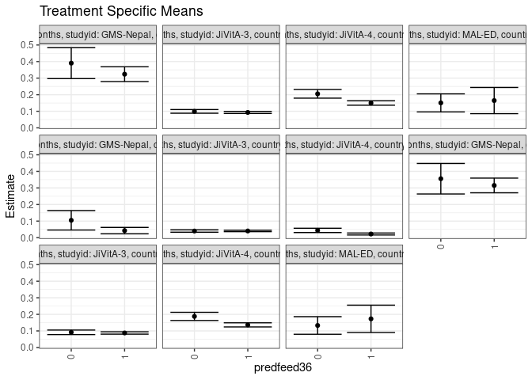

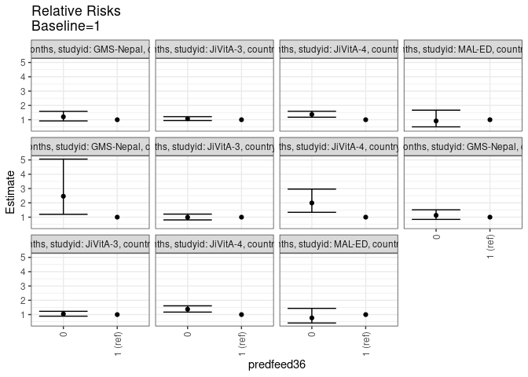

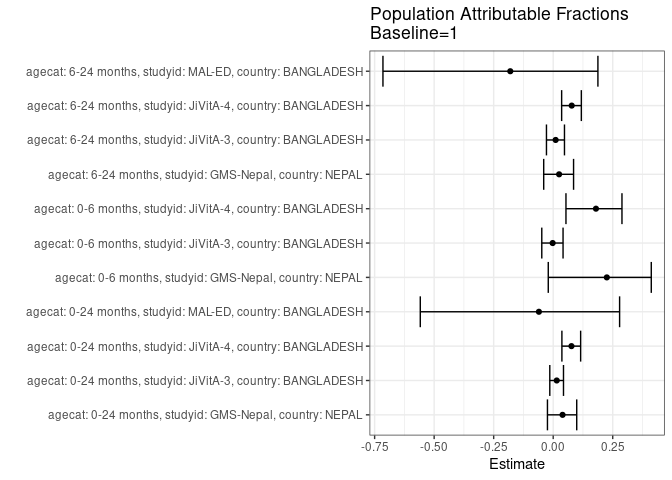

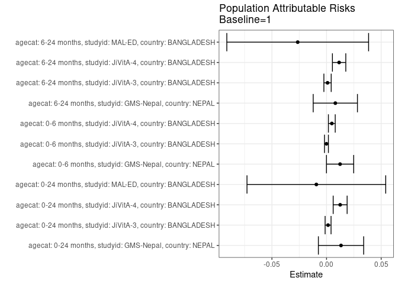

## Results Table

### Parameter: TSM

| agecat | studyid | country | intervention_level | baseline_level | estimate | ci_lower | ci_upper |
| --- | --- | --- | --- | --- | --- | --- | --- |
| 0-24 months | GMS-Nepal | NEPAL | 1 | NA | 0.3238771 | 0.2792403 | 0.3685138 |
| 0-24 months | GMS-Nepal | NEPAL | 0 | NA | 0.3904762 | 0.2970739 | 0.4838785 |
| 0-24 months | JiVitA-3 | BANGLADESH | 1 | NA | 0.0930396 | 0.0868523 | 0.0992270 |
| 0-24 months | JiVitA-3 | BANGLADESH | 0 | NA | 0.0994298 | 0.0883500 | 0.1105096 |
| 0-24 months | JiVitA-4 | BANGLADESH | 1 | NA | 0.1498875 | 0.1366638 | 0.1631112 |
| 0-24 months | JiVitA-4 | BANGLADESH | 0 | NA | 0.2052275 | 0.1792158 | 0.2312392 |
| 0-24 months | MAL-ED | BANGLADESH | 1 | NA | 0.1647059 | 0.0856963 | 0.2437155 |
| 0-24 months | MAL-ED | BANGLADESH | 0 | NA | 0.1506024 | 0.0960854 | 0.2051195 |
| 0-6 months | GMS-Nepal | NEPAL | 1 | NA | 0.0425532 | 0.0232995 | 0.0618068 |
| 0-6 months | GMS-Nepal | NEPAL | 0 | NA | 0.1047619 | 0.0461297 | 0.1633941 |
| 0-6 months | JiVitA-3 | BANGLADESH | 1 | NA | 0.0404193 | 0.0361959 | 0.0446427 |
| 0-6 months | JiVitA-3 | BANGLADESH | 0 | NA | 0.0400000 | 0.0328471 | 0.0471529 |
| 0-6 months | JiVitA-4 | BANGLADESH | 1 | NA | 0.0220464 | 0.0160454 | 0.0280473 |
| 0-6 months | JiVitA-4 | BANGLADESH | 0 | NA | 0.0439122 | 0.0309534 | 0.0568709 |
| 6-24 months | GMS-Nepal | NEPAL | 1 | NA | 0.3151659 | 0.2707981 | 0.3595336 |
| 6-24 months | GMS-Nepal | NEPAL | 0 | NA | 0.3557692 | 0.2636714 | 0.4478671 |
| 6-24 months | JiVitA-3 | BANGLADESH | 1 | NA | 0.0876084 | 0.0805268 | 0.0946900 |
| 6-24 months | JiVitA-3 | BANGLADESH | 0 | NA | 0.0915879 | 0.0779014 | 0.1052743 |
| 6-24 months | JiVitA-4 | BANGLADESH | 1 | NA | 0.1364149 | 0.1240425 | 0.1487873 |
| 6-24 months | JiVitA-4 | BANGLADESH | 0 | NA | 0.1875607 | 0.1628605 | 0.2122610 |
| 6-24 months | MAL-ED | BANGLADESH | 1 | NA | 0.1728395 | 0.0903246 | 0.2553544 |
| 6-24 months | MAL-ED | BANGLADESH | 0 | NA | 0.1329114 | 0.0798666 | 0.1859562 |

### Parameter: E(Y)

| agecat | studyid | country | intervention_level | baseline_level | estimate | ci_lower | ci_upper |
| --- | --- | --- | --- | --- | --- | --- | --- |
| 0-24 months | GMS-Nepal | NEPAL | NA | NA | 0.3371212 | 0.2967611 | 0.3774814 |
| 0-24 months | JiVitA-3 | BANGLADESH | NA | NA | 0.0944462 | 0.0888980 | 0.0999944 |
| 0-24 months | JiVitA-4 | BANGLADESH | NA | NA | 0.1623447 | 0.1503363 | 0.1743531 |
| 0-24 months | MAL-ED | BANGLADESH | NA | NA | 0.1553785 | 0.1104725 | 0.2002845 |
| 0-6 months | GMS-Nepal | NEPAL | NA | NA | 0.0549242 | 0.0354725 | 0.0743760 |
| 0-6 months | JiVitA-3 | BANGLADESH | NA | NA | 0.0403270 | 0.0366289 | 0.0440252 |
| 0-6 months | JiVitA-4 | BANGLADESH | NA | NA | 0.0268722 | 0.0213332 | 0.0324113 |
| 6-24 months | GMS-Nepal | NEPAL | NA | NA | 0.3231939 | 0.2831873 | 0.3632006 |
| 6-24 months | JiVitA-3 | BANGLADESH | NA | NA | 0.0885157 | 0.0819350 | 0.0950963 |
| 6-24 months | JiVitA-4 | BANGLADESH | NA | NA | 0.1479135 | 0.1367519 | 0.1590750 |
| 6-24 months | MAL-ED | BANGLADESH | NA | NA | 0.1464435 | 0.1015265 | 0.1913605 |

### Parameter: RR

| agecat | studyid | country | intervention_level | baseline_level | estimate | ci_lower | ci_upper |
| --- | --- | --- | --- | --- | --- | --- | --- |
| 0-24 months | GMS-Nepal | NEPAL | 1 | 1 | 1.0000000 | 1.0000000 | 1.000000 |
| 0-24 months | GMS-Nepal | NEPAL | 0 | 1 | 1.2056309 | 0.9147894 | 1.588940 |
| 0-24 months | JiVitA-3 | BANGLADESH | 1 | 1 | 1.0000000 | 1.0000000 | 1.000000 |
| 0-24 months | JiVitA-3 | BANGLADESH | 0 | 1 | 1.0686822 | 0.9422393 | 1.212093 |
| 0-24 months | JiVitA-4 | BANGLADESH | 1 | 1 | 1.0000000 | 1.0000000 | 1.000000 |
| 0-24 months | JiVitA-4 | BANGLADESH | 0 | 1 | 1.3692101 | 1.1771005 | 1.592673 |
| 0-24 months | MAL-ED | BANGLADESH | 1 | 1 | 1.0000000 | 1.0000000 | 1.000000 |
| 0-24 months | MAL-ED | BANGLADESH | 0 | 1 | 0.9143718 | 0.5013367 | 1.667693 |
| 0-6 months | GMS-Nepal | NEPAL | 1 | 1 | 1.0000000 | 1.0000000 | 1.000000 |
| 0-6 months | GMS-Nepal | NEPAL | 0 | 1 | 2.4619048 | 1.1987106 | 5.056246 |
| 0-6 months | JiVitA-3 | BANGLADESH | 1 | 1 | 1.0000000 | 1.0000000 | 1.000000 |
| 0-6 months | JiVitA-3 | BANGLADESH | 0 | 1 | 0.9896259 | 0.8069553 | 1.213648 |
| 0-6 months | JiVitA-4 | BANGLADESH | 1 | 1 | 1.0000000 | 1.0000000 | 1.000000 |
| 0-6 months | JiVitA-4 | BANGLADESH | 0 | 1 | 1.9918112 | 1.3389505 | 2.963001 |
| 6-24 months | GMS-Nepal | NEPAL | 1 | 1 | 1.0000000 | 1.0000000 | 1.000000 |
| 6-24 months | GMS-Nepal | NEPAL | 0 | 1 | 1.1288317 | 0.8407269 | 1.515666 |
| 6-24 months | JiVitA-3 | BANGLADESH | 1 | 1 | 1.0000000 | 1.0000000 | 1.000000 |
| 6-24 months | JiVitA-3 | BANGLADESH | 0 | 1 | 1.0454231 | 0.8890863 | 1.229250 |
| 6-24 months | JiVitA-4 | BANGLADESH | 1 | 1 | 1.0000000 | 1.0000000 | 1.000000 |
| 6-24 months | JiVitA-4 | BANGLADESH | 0 | 1 | 1.3749287 | 1.1735183 | 1.610907 |
| 6-24 months | MAL-ED | BANGLADESH | 1 | 1 | 1.0000000 | 1.0000000 | 1.000000 |
| 6-24 months | MAL-ED | BANGLADESH | 0 | 1 | 0.7689873 | 0.4127417 | 1.432716 |

### Parameter: PAR

| agecat | studyid | country | intervention_level | baseline_level | estimate | ci_lower | ci_upper |
| --- | --- | --- | --- | --- | --- | --- | --- |
| 0-24 months | GMS-Nepal | NEPAL | 1 | NA | 0.0132441 | -0.0074670 | 0.0339553 |
| 0-24 months | JiVitA-3 | BANGLADESH | 1 | NA | 0.0014066 | -0.0013077 | 0.0041208 |
| 0-24 months | JiVitA-4 | BANGLADESH | 1 | NA | 0.0124572 | 0.0060768 | 0.0188376 |
| 0-24 months | MAL-ED | BANGLADESH | 1 | NA | -0.0093274 | -0.0728181 | 0.0541633 |
| 0-6 months | GMS-Nepal | NEPAL | 1 | NA | 0.0123711 | -0.0000831 | 0.0248252 |
| 0-6 months | JiVitA-3 | BANGLADESH | 1 | NA | -0.0000923 | -0.0018937 | 0.0017091 |
| 0-6 months | JiVitA-4 | BANGLADESH | 1 | NA | 0.0048259 | 0.0017085 | 0.0079433 |
| 6-24 months | GMS-Nepal | NEPAL | 1 | NA | 0.0080280 | -0.0122316 | 0.0282877 |
| 6-24 months | JiVitA-3 | BANGLADESH | 1 | NA | 0.0009073 | -0.0024463 | 0.0042608 |
| 6-24 months | JiVitA-4 | BANGLADESH | 1 | NA | 0.0114986 | 0.0053877 | 0.0176095 |
| 6-24 months | MAL-ED | BANGLADESH | 1 | NA | -0.0263960 | -0.0912893 | 0.0384973 |

### Parameter: PAF

| agecat | studyid | country | intervention_level | baseline_level | estimate | ci_lower | ci_upper |
| --- | --- | --- | --- | --- | --- | --- | --- |
| 0-24 months | GMS-Nepal | NEPAL | 1 | NA | 0.0392860 | -0.0241518 | 0.0987943 |
| 0-24 months | JiVitA-3 | BANGLADESH | 1 | NA | 0.0148927 | -0.0142865 | 0.0432325 |
| 0-24 months | JiVitA-4 | BANGLADESH | 1 | NA | 0.0767332 | 0.0365437 | 0.1152461 |
| 0-24 months | MAL-ED | BANGLADESH | 1 | NA | -0.0600302 | -0.5582518 | 0.2788945 |
| 0-6 months | GMS-Nepal | NEPAL | 1 | NA | 0.2252384 | -0.0207122 | 0.4119249 |
| 0-6 months | JiVitA-3 | BANGLADESH | 1 | NA | -0.0022886 | -0.0479547 | 0.0413875 |
| 0-6 months | JiVitA-4 | BANGLADESH | 1 | NA | 0.1795865 | 0.0535958 | 0.2888046 |
| 6-24 months | GMS-Nepal | NEPAL | 1 | NA | 0.0248397 | -0.0398991 | 0.0855482 |
| 6-24 months | JiVitA-3 | BANGLADESH | 1 | NA | 0.0102496 | -0.0283000 | 0.0473541 |
| 6-24 months | JiVitA-4 | BANGLADESH | 1 | NA | 0.0777387 | 0.0354475 | 0.1181756 |
| 6-24 months | MAL-ED | BANGLADESH | 1 | NA | -0.1802469 | -0.7150376 | 0.1877830 |